# Chapter 2: Understanding Data Mining

# Understanding Data Mining

Chapter Summary: This chapter introduces some basic concepts of data mining with simple examples in R.

*Data Mining* is a computational process for discovering meaningful patterns in large sets of data.

https://en.wikipedia.org/wiki/Data_mining

Data Mining is used in almost every discipline to learn from the rapidly expanding troves of data generated by modern computer technology.

# Data Mining Process

The data mining community has produced a number of standards to help people implement the data mining process. In this class, we will sometimes refer to *CRISP-DM*, Cross Industry Standard Process for Data Mining.

https://en.wikipedia.org/wiki/Cross_Industry_Standard_Process_for_Data_Mining

The CRISP-DM method includes the following phases:

## Project Understanding

- In this phase, we try to understand the problem from the point of view of the business or research objectives.
- These real-world objectives are translated into specific data mining objectives.

## Data Understanding

This phase can include:

- data collection;
- preliminary data analysis;
- data quality review.

## Data Preparation

Data preparation takes the data in its initial form and transforms it into its final form for analysis. This may include many steps such as:

- Outlier analysis
- Handling missing values
- Separating data into training and testing sets

## Modeling

- Data mining models are used to “mine” the data set for information relevant to the problem.
- *Descriptive models* construct accurate portrayals of some aspect of the real world with data.
- *Exploratory models* help researchers to discover insights in their data.
- *Explanatory models* aim to identify causal relationships in data.
- *Predictive models* forecast real-world outcomes based on data.

## Evaluation

- The results of the modeling phase are put into perspective and tested where possible.
- Do the results meet the needs of the project?

## Deployment

- Implement the model for business or research purposes.
- Document the knowledge generated from this process.

# Types of Modeling in Data Mining

## Descriptive Modeling

Descriptive modeling attempts to provide an accurate portrayal of some aspect of the real world with data.

*Problem Understanding*

Sometimes, we want to understand how to compare things. We often do this in sports. People like to argue about their favorite players based on their statistics. Suppose I am a Rod Carew fan and I wanted to understand Carew’s career statistics. In other words, I want to answer the question: how good of a batter was Rod Carew?

We might use descriptive modeling to help us answer this question.

To make the example straight forward, let’s assume that a career batting average is a good way to summarize a batter’s career (even though it isn’t).

So we can formalize our problem with a more specific question based on our data model.

How does Rod Carew’s batting average compare to that of other players?

It’s very important to recognize that we’ve already made a crucial modeling decision. We’ve assumed that batting averages provide a decent basis for comparing the performance of batters.

*Data Understanding*

In the data understanding phase, we’ll want to make sure that we understand batting averages (our data model). We’ll also want to make sure that we can get the data we need. Luckily, we can get the data from a handy reference site: http://www.baseball-reference.com/leaders/batting_avg_career.shtml

*Data Preparation*

Unfortunately, we can’t use the data as it is published on the website. We will need to cleanse the data to make sure that we can use it properly.

We will need to install packages that can help us cleanse our data.

```
install.packages('rvest')
install.packages('stringr')
install.packages('tidyr')
```

Then we need to load those packages to make them available to our program.

```r
library(rvest)
library(stringr)
library(tidyr)
library(xml2)
```

Now we are reading to cleanse our data.

- We read the html page with the data we want.
- We extract the HTML tables from the webpage.
- We extract the first HTML table.

```r
batters <- "http://www.baseball-reference.com/leaders/batting_avg_career.shtml"
webpage <- read_html(batters)
sb_table <- html_nodes(webpage, 'table')
sb <- html_table(sb_table)[[1]]
head(sb)
```

```
##   Rank         Player (yrs, age) Batting Average Bats
## 1   1.             Ty Cobb+ (24)           .3664    L
## 2   2.      Rogers Hornsby+ (23)           .3585    R
## 3   3. Shoeless Joe Jackson (13)           .3558    L
## 4   4.         Lefty O'Doul (11)           .3493    L
## 5   5.        Ed Delahanty+ (16)           .3458    R
## 6   6.        Tris Speaker+ (22)           .3447    L
```

- We only need columns 2 and 3 for our analysis.
- We want to be sure that the batting averages are treating as numeric data types.

```r
bat <- sb[,2:3]
bat[,2] <- as.numeric(sb[,3])
```

- We have to remove records with batting averages that do not represent numbers.

```r
bat[is.na(bat[,2]),]
```

```
##     Player (yrs, age) Batting Average
## 51  Player (yrs, age)              NA
## 102 Player (yrs, age)              NA
## 153 Player (yrs, age)              NA
## 204 Player (yrs, age)              NA
## 255 Player (yrs, age)              NA
## 306 Player (yrs, age)              NA
## 357 Player (yrs, age)              NA
## 408 Player (yrs, age)              NA
## 459 Player (yrs, age)              NA
## 510 Player (yrs, age)              NA
## 561 Player (yrs, age)              NA
## 612 Player (yrs, age)              NA
## 663 Player (yrs, age)              NA
## 714 Player (yrs, age)              NA
## 765 Player (yrs, age)              NA
## 816 Player (yrs, age)              NA
## 867 Player (yrs, age)              NA
## 918 Player (yrs, age)              NA
## 969 Player (yrs, age)              NA
```

```r
bat <- bat[!is.na(bat[,2]),]
```

- Finally we have the data in a format we can process.

```r
summary(bat)
```

```
##  Player (yrs, age)  Batting Average
##  Length:999         Min.   :0.2694
##  Class :character   1st Qu.:0.2761
##  Mode  :character   Median :0.2852
##                     Mean   :0.2888
##                     3rd Qu.:0.2969
##                     Max.   :0.3664
```

```r
str(bat)
```

```
## 'data.frame':    999 obs. of  2 variables:
##  $ Player (yrs, age): chr  "Ty Cobb+ (24)" "Rogers Hornsby+ (23)" "Shoeless Joe Jackson (13)" "Lefty O'Doul (11)" ...
##  $ Batting Average  : num  0.366 0.358 0.356 0.349 0.346 ...
```

*Modeling*

We will model a single variable: batting average. This should help us put Rod Carew’s career batting into perspective.

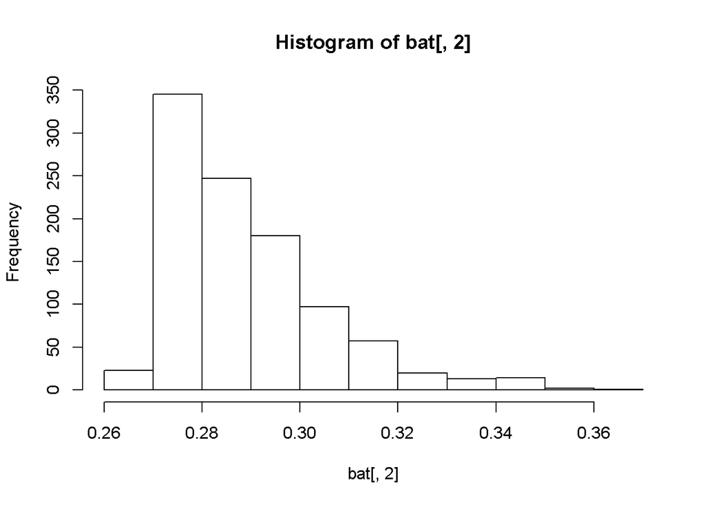

Histogram of Batting Averages

[figure not shown]

```r
hist(bat[,2])
```

Density Plot of Batting Averages

```r
plot(density(bat[,2]))
abline(v = .3278, col="red")
```

*Evaluation*

Do our results shed light on our original problem? Rod Carew’s batting average does look elite even in this sample. What’s more, Carew might be in a very small group of extremely elite batters.

Are there problems with our approach? We are comparing Carew’s numbers to other elite batters. In other words, this isn’t a random sample of batters: it’s biased toward good batters. Given our question, this is not really a problem, but it’s always a good idea to consider the bias in our samples.

What else can we learn from these data? In the distribution, we see both a big bump of good batters and a small bump of great batters. We might like to know if Carew is closer to the big group or small group. We’ll examine this question in our example of exploratory modeling.

*Deployment*

In this case, deployment might mean simply reporting our results to peers.

## Exploratory Modeling

Exploratory models help researchers to discover insights in their data.

*Problem Understanding*

We still want to put Carew’s batting average in perspective. When we performed descriptive modeling, we identified two different bumps in the distribution of the batters: good and great.

We want to use that observation to help us see if Carew’s metrics are more like the good or the great batters.

We can formalize this by performing cluster analysis which is a common approach to exploratory modeling.

*Data Understanding*

Since we performed our data analysis already, we already understand these data pretty well.

*Data Preparation*

We’ve also already formatted our data in a pretty good state. We will need to perform a few steps to perform clustering analysis.

First, we need to create a distance matrix which estimates the distance between every batter and every other batter based on their batting averages.

```r
d <- dist(bat[,2])
head(d)
```

```
## [1] 0.0079 0.0106 0.0171 0.0206 0.0217 0.0220
```

*Modeling*

The distance matrix serves as input to the hierarchical clustering algorithm. Since we know from our descriptive model, we expect two clusters and we show each cluster in a red box.

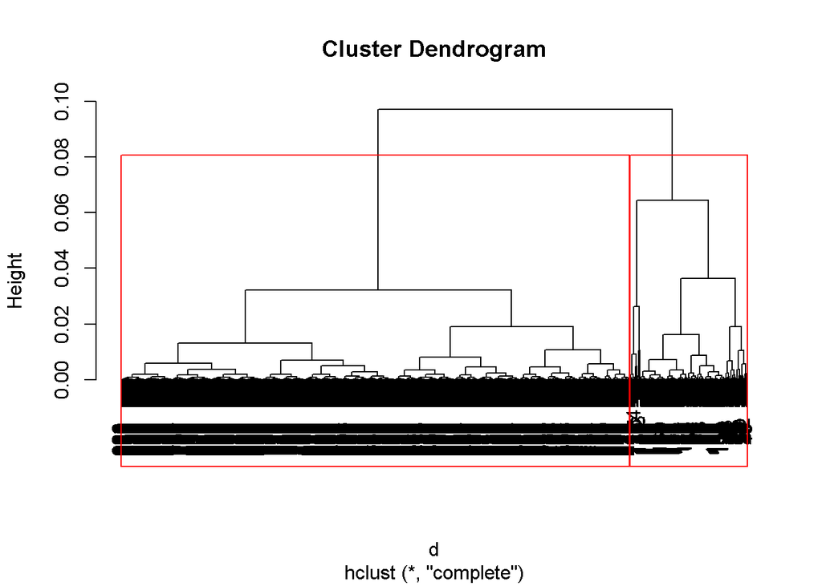

Dendrogram of Hierarchical Cluster of Batters

```r
h <- hclust(d)
plot(h)
rect.hclust(h, k = 2, border = "red")
```

*Evaluation*

It looks like we have good reason to believe that Rod Carew should be considered among the greatest of batters. He easily falls into the cluster of great batters. We might to try additional clustering techniques or validate our choice of two clusters in these data.

```r
ct <- cutree(h, 2)
table(ct)
```

```
## ct
##   1   2
## 188 811
```

We can see that the first 188 batters are in the elite group which includes Rod Carew.

*Deployment*

Again, deployment in this case might simply be using our knowledge and visualizations to help document our case.

## Explanatory Modeling

Explanatory models aim to identify causal relationships in data.

*Problem Understanding*

We want to understand how smoking affects our health. In other words, we want to explain the relationship between smoking cigarettes and lifespan.

We can formalize this by comparing people’s smoking habits with their longevity. In such cases, researchers often use linear regression.

*Data Understanding*

Consider the following dataset. Source: http://www.real-statistics.com/correlation/one-sample-hypothesis-testing-correlation/

The dataset collects the smoking behavior and longevity of 15 males 50 or above.

“Cigarettes” measures the average number of cigarettes smoked per day.

“Longevity” measures each participant’s age in years at the time of his death.

*Data Preparation*

Since the data were collected as part of an experiment, the data are already fairly well prepared. We can read them and review them for good measure.

```r
data <- read.csv("cigarettes.csv")
summary(data)
```

```
##    cigarettes     longevity
##  Min.   : 4.0   Min.   :53.00
##  1st Qu.: 9.5   1st Qu.:66.50
##  Median :19.0   Median :75.00
##  Mean   :19.4   Mean   :73.53
##  3rd Qu.:25.5   3rd Qu.:80.50
##  Max.   :48.0   Max.   :92.00
```

*Modeling*

We will use a linear regression model to identify how cigarettes affect health as measured by longevity.

We start by looking at the correlation between these two variables.

```r
cor(data)
```

```
##            cigarettes  longevity
## cigarettes  1.0000000 -0.7134302
## longevity  -0.7134302  1.0000000
```

```r
cor.test(data$cigarettes,data$longevity)
```

```
##
##  Pearson's product-moment correlation
##
## data:  data$cigarettes and data$longevity
## t = -3.6709, df = 13, p-value = 0.002822
## alternative hypothesis: true correlation is not equal to 0
## 95 percent confidence interval:
##  -0.8976386 -0.3170305
## sample estimates:
##        cor
## -0.7134302
```

We can see that there is a negative relationship between smoking and longevity. It can be helpful to plot these variables to confirm that their relationship represents a linear relationship.

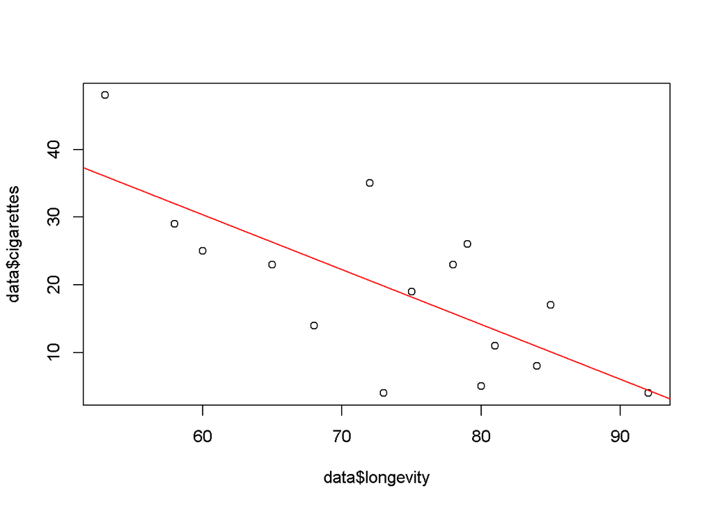

```r
plot(data$longevity,data$cigarettes)
abline(lm(data$cigarettes ~ data$longevity), col="red")
```

The fitted line does more or less represent the center of the data in the scatter plot. So we have decent reason to believe that there is a linear relationship between the two variables.

Now we can create a linear regression formula to explain the relationship between these variables more formally.

```r
lmfit <- lm(longevity ~ cigarettes, data=data)
lmfit
```

```
##
## Call:
## lm(formula = longevity ~ cigarettes, data = data)
##
## Coefficients:
## (Intercept)   cigarettes
##     85.7204      -0.6282
```

*Evaluation*

At this point, we want to make sure that the regression formula is a reasonable explanatory model.

```r
summary(lmfit)
```

```
##
## Call:
## lm(formula = longevity ~ cigarettes, data = data)
##
## Residuals:
##     Min      1Q  Median      3Q     Max
## -10.208  -7.599   1.215   7.497   9.959
##
## Coefficients:
##             Estimate Std. Error t value Pr(>|t|)
## (Intercept)  85.7204     3.9066  21.943 1.18e-11 ***
## cigarettes   -0.6282     0.1711  -3.671  0.00282 **
## ---
## Signif. codes:  0 '***' 0.001 '**' 0.01 '*' 0.05 '.' 0.1 ' ' 1
##
## Residual standard error: 7.975 on 13 degrees of freedom
## Multiple R-squared:  0.509,  Adjusted R-squared:  0.4712
## F-statistic: 13.48 on 1 and 13 DF,  p-value: 0.002822
```

In order to evaluate this model, we want to know:

1. How likely is this model the result of random variation?

The p-value (probability value) associated with the F-statistic tells us that the model is unlikely to be the result of random variation. In other words, we have a statistically significant fit.

2. How much of the variation in the data does our model explain?

The adjusted R-squared value tells us that our linear model explains just a bit less than half of the variation found in the data.

Although these are reasonable results, we will want to consider the limits of our model including:

1. Our model is way too simple. Clearly other things contribute to health beside smoking. We probably want to consider other variables that will help us understand this problem better.
2. Our model is biased because it only samples males over 50. We almost certainly want to include gender in our model as well.

*Deployment*

As in previous examples, we will want to document our work thoroughly.

## Predictive Modeling

Predictive models forecast real-world outcomes based on data.

*Problem Understanding*

Now we would like to predict how long our 55 year old friend will live who smokes 25 cigarettes a day on average.

*Data Understanding*

We have already spent some time reviewing the data when we created our explanatory model. We can move forward at this point.

*Data Preparation*

Since predictive models often require training sets and testing sets, the data preparation phase must include the creation of these data sets.

We will use the data frame from our explanatory model as our training set. Then we will create our testing set with the data specific to our friend.

```r
newdata <- data.frame(cigarettes=25,longevity=0)
```

*Modeling*

We now use our model to predict our friend’s longevity based on his smoking behavior.

```r
predict(lmfit, newdata=newdata)
```

```
##        1
## 70.01541
```

*Evaluation*

Since we can’t immediately evaluate our prediction, we’ll need to be creative when trying to assess our model. Data mining is a repetitive process. We will need to refine this model on a repeated basis to respond to new trends and data.

*Deployment*

We may want to deploy our formula to a website to help people think about the health consequences of their behavior.

# Summary

In this chapter, we learned about the data mining process and four different types of models we will use in our data mining projects.

# References

R Core Team (2016). R: A language and environment for statistical computing. R Foundation for Statistical Computing, Vienna, Austria. URL https://www.R-project.org/.